# Assignment 5

Jamie K. Miller

November 28, 2018

## 1. Male and Female graduate enrollment (1967 - 2015)

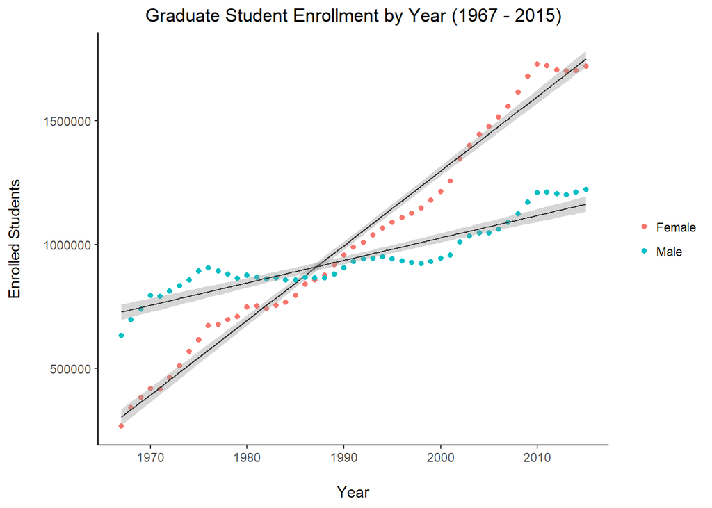

**Figure 1. Graduate strudent enrollment by year from 1967 to 2015.** Fall enrollment of female and male students each year from 1967 to 2015. *Source: U.S. Department of Education, National Center for Education Statistics, Higher Education General Information Survey (HEGIS), “Fall Enrollment in Colleges and Universities” surveys, 1967 through 1985; Integrated Postsecondary Education Data System (IPEDS), “Fall Enrollment Survey” (IPEDS-EF:86-99); IPEDS Spring 2001 through Spring 2016, Fall Enrollment component. Prepared February 2017.*

Graduate enrollment of female students is significantly predicted by year (*b* = 30126, t(47) = 51.66, *p* < 0.001) with a strong positive correlation between the two (Pearson’s *r* = 0.99. The model (*enrolled students* = 30126(*Year*) - 58955502) explains a significant amount of variance in female graduate student enrollment (F(1,47) = 2669, *p* < 0.001, R<sup>2</sup> = 0.98).

Similarly, the model (*enrolled students* = 9069(*Year*) - 17112153) explains a significant amount of variance in male graduate student enrollment (F(1,47) = 276, *p* < 0.001, R<sup>2</sup> = 0.85). Graduate enrollment of male students is also significantly predicted by year (*b* = 9069, t(47) = 16.61, *p* < 0.001) with a strong positive correlation between the two (Pearson’s *r* = 0.92.

Graduate enrollment generally increased for both male and female students from 1967 to 2015, though enrollment of female graduate students increased faster than enrollment of male students. In 1967 women comprised 29.6% of all enrolled graduate students. The sex ratio of graduate students switched from to male-biased to female biased in 1988 when the percentage of female students increased from 49.8% of all students in 1987 to 50.3% in 1988. By 2015, 58.5% of graduate students were female. In recent years, enrollment leveled and even decreased slightly staring in 2010 following the 2008/2009 financial crisis.

## Part 4. Exploring academic salaries for professors in U.S. colleges.

#### First by Rank

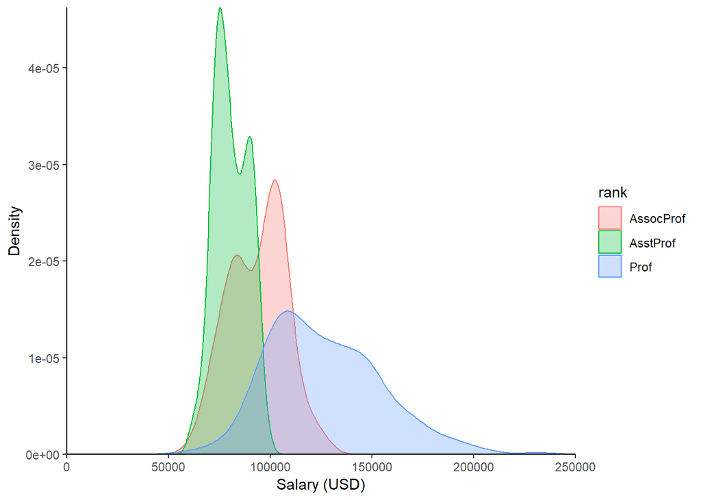

```r
# Part 4. Exploring academic salaries for professors in U.S. colleges.
# Faculty salary by rank, discipline, experience and sex

# Calculate mean salary by rank
mean_by_rank <- faculty_salary_2008_2009 %>%
  group_by(rank) %>%
  summarize(
    mean = mean(salary)
  )

# Visualize salary by rank
by_rank <- ggplot(faculty_salary_2008_2009, aes(x = salary)) +
  geom_density(aes(color = rank, fill = rank), alpha = 0.3) +
  theme_classic() +
  scale_x_continuous(expand = c(0,0), limits = c(0,250000)) +
  scale_y_continuous(expand = c(0,0)) +
  labs(x = "Salary (USD)", y = "Density")

by_rank
```

```r
# So far, graphically, this appears to be the biggest driver.
```

#### By Sex

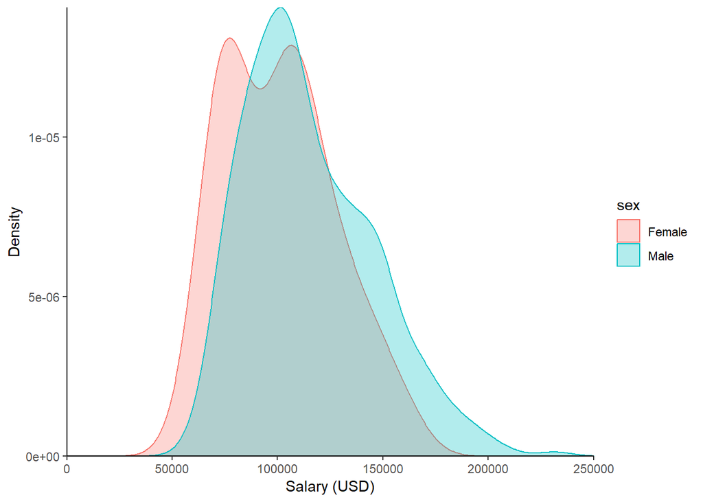

```r
# Part 4. Exploring academic salaries for professors in U.S. colleges.
# Faculty salary by rank, discipline, experience and sex

# Calculate mean salary by sex
mean_by_sex <- faculty_salary_2008_2009 %>%
  group_by(sex) %>%
  summarize(
    mean = mean(salary)
  )

# Visualize salary by sex
by_sex <- ggplot(faculty_salary_2008_2009, aes(x = salary)) +
  geom_density(aes(color = sex, fill = sex), alpha = 0.3) +
  theme_classic() +
  scale_x_continuous(expand = c(0,0), limits = c(0,250000)) +
  scale_y_continuous(expand = c(0,0)) +
  labs(x = "Salary (USD)", y = "Density")

by_sex
```

#### By Field

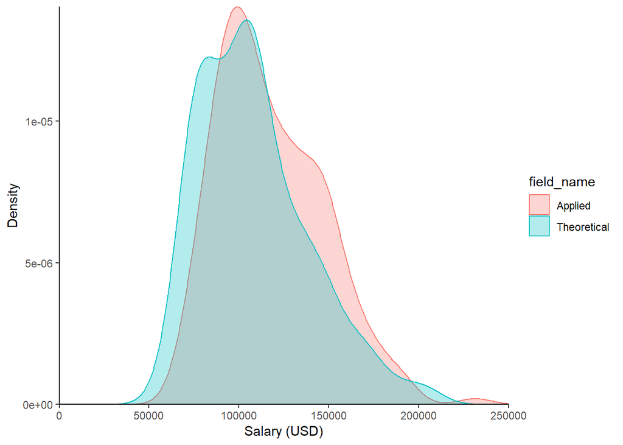

```r
# Part 4. Exploring academic salaries for professors in U.S. colleges.
# Faculty salary by rank, discipline, experience and sex
# Discipline (A = Theoretical, B = Applied) changed to 'field'

# Calculate mean salary by Experience - Years Since PhD
mean_by_field <- faculty_salary_2008_2009 %>%
  group_by(field_name) %>%
  summarize(
    mean = mean(salary)
  )

# Visualize salary by Experience - Years Since PhD
by_field <- ggplot(faculty_salary_2008_2009, aes(x = salary)) +
  geom_density(aes(color = field_name, fill = field_name), alpha = 0.3) +
  theme_classic() +
  scale_x_continuous(expand = c(0,0), limits = c(0,250000)) +
  scale_y_continuous(expand = c(0,0)) +
  labs(x = "Salary (USD)", y = "Density")

by_field
```

#### By Years Experience

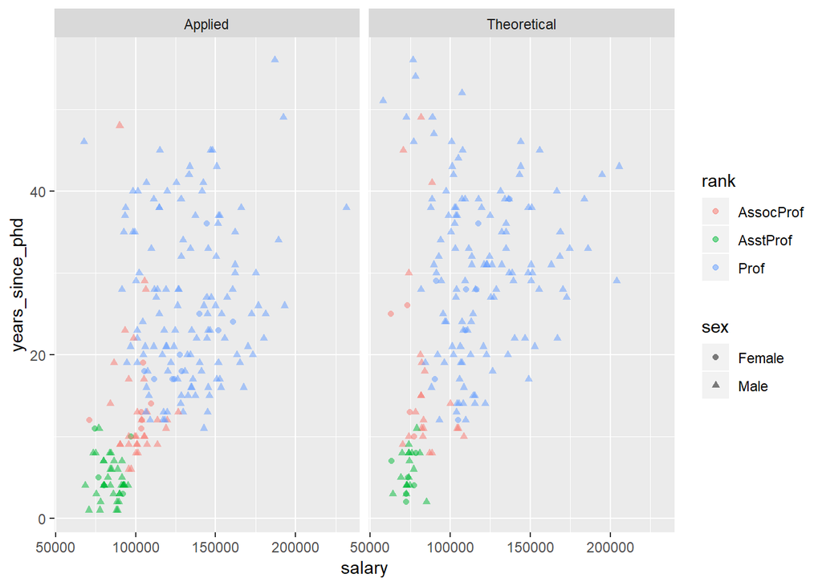

```r
# Part 4. Exploring academic salaries for professors in U.S. colleges.
# Faculty salary by rank, discipline, experience and sex

# Since yrs after phd and yrs service are continuous, and possibly collinear, will show them graphically.

by_yrs_phd <- ggplot(faculty_salary_2008_2009, aes(x = salary, y = years_since_phd)) +
  geom_point(aes(color = rank, pch = sex), alpha = 0.5) +
  facet_wrap(~field_name)

by_yrs_phd
```

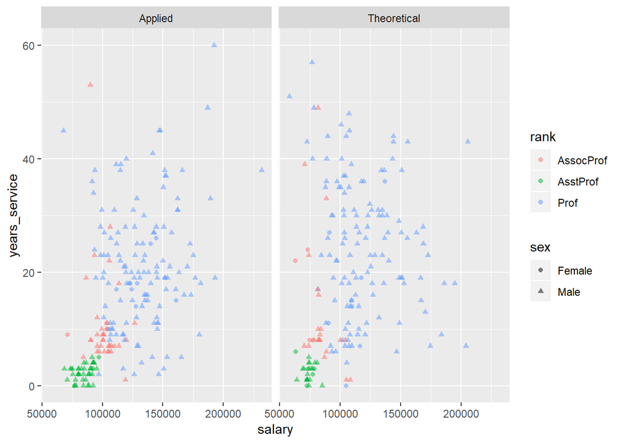

```r
# Does years service look the same?

by_yrs_service <- ggplot(faculty_salary_2008_2009, aes(x = salary, y = years_service)) +
  geom_point(aes(color = rank, pch = sex), alpha = 0.5) +
  facet_wrap(~field_name)

by_yrs_service
```

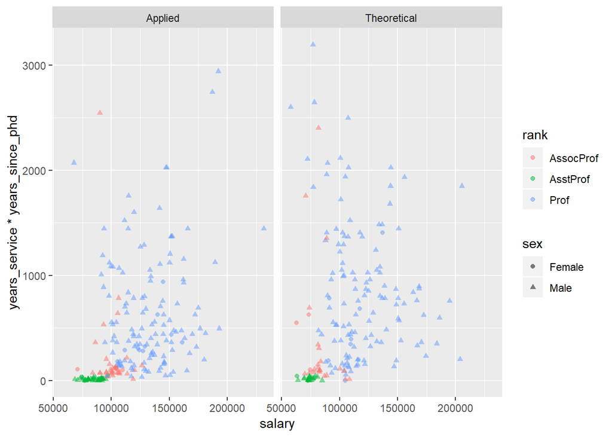

```r
# Similar trend, but not the same. Might be collinear. Should test.

by_yrs_interaction <- ggplot(faculty_salary_2008_2009, aes(x = salary, y = years_service*years_since_phd)) +
  geom_point(aes(color = rank, pch = sex), alpha = 0.5) +
  facet_wrap(~field_name)

by_yrs_interaction
```

```r
# Part 4. Exploring academic salaries for professors in U.S. colleges.
# Faculty salary by rank, discipline, experience and sex
# LM with all factors
# change rank reference level from AssocProf to AsstProf since it is the lowest. change from character to factor

faculty_salary_2008_2009$rank <- factor(faculty_salary_2008_2009$rank)

faculty_salary_2008_2009$rank <- fct_relevel(faculty_salary_2008_2009$rank, "AsstProf")

faculty_salary_lm2 <- lm(salary ~ rank + field_name + sex + years_since_phd + years_service, data = faculty_salary_2008_2009)

summary(faculty_salary_lm2)
```

```
##
## Call:
## lm(formula = salary ~ rank + field_name + sex + years_since_phd +
##     years_service, data = faculty_salary_2008_2009)
##
## Residuals:
##    Min     1Q Median     3Q    Max
## -65248 -13211  -1775  10384  99592
##
## Coefficients:
##                       Estimate Std. Error t value Pr(>|t|)
## (Intercept)            80372.9     4372.3  18.382  < 2e-16 ***
## rankAssocProf          12907.6     4145.3   3.114  0.00198 **
## rankProf               45066.0     4237.5  10.635  < 2e-16 ***
## field_nameTheoretical -14417.6     2342.9  -6.154 1.88e-09 ***
## sexMale                 4783.5     3858.7   1.240  0.21584
## years_since_phd          535.1      241.0   2.220  0.02698 *
## years_service           -489.5      211.9  -2.310  0.02143 *
## ---
## Signif. codes:  0 '***' 0.001 '**' 0.01 '*' 0.05 '.' 0.1 ' ' 1
##
## Residual standard error: 22540 on 390 degrees of freedom
## Multiple R-squared:  0.4547, Adjusted R-squared:  0.4463
## F-statistic:  54.2 on 6 and 390 DF,  p-value: < 2.2e-16
```

```r
# Part 4. Exploring academic salaries for professors in U.S. colleges.
# Faculty salary by rank, discipline, experience and sex
# LM with all factors
# Add interaction term between yrs_service and yrs_since_phd

faculty_salary_lm6 <- lm(salary ~ rank + field_name + sex + years_since_phd + years_service + years_since_phd*years_service, data = faculty_salary_2008_2009)

summary(faculty_salary_lm6)
```

```
##
## Call:
## lm(formula = salary ~ rank + field_name + sex + years_since_phd +
##     years_service + years_since_phd * years_service, data = faculty_salary_2008_2009)
##
## Residuals:
##    Min     1Q Median     3Q    Max
## -59899 -12530  -1537   9649  99328
##
## Coefficients:
##                                 Estimate Std. Error t value Pr(>|t|)
## (Intercept)                    75594.923   4690.437  16.117  < 2e-16 ***
## rankAssocProf                   6140.317   4826.750   1.272 0.204082
## rankProf                       34357.943   5801.366   5.922 6.98e-09 ***
## field_nameTheoretical         -14316.705   2324.848  -6.158 1.84e-09 ***
## sexMale                         5448.304   3836.511   1.420 0.156374
## years_since_phd                 1032.650    302.783   3.411 0.000716 ***
## years_service                    348.108    376.819   0.924 0.356161
## years_since_phd:years_service    -24.691      9.217  -2.679 0.007703 **
## ---
## Signif. codes:  0 '***' 0.001 '**' 0.01 '*' 0.05 '.' 0.1 ' ' 1
##
## Residual standard error: 22360 on 389 degrees of freedom
## Multiple R-squared:  0.4646, Adjusted R-squared:  0.4549
## F-statistic: 48.21 on 7 and 389 DF,  p-value: < 2.2e-16
```

```r
# Part 4. Exploring academic salaries for professors in U.S. colleges.
# Faculty salary by rank, discipline, experience and sex
# LM with all factors  - remove sigle factors yrs_service and yrs_since_phd
# Add interaction term between yrs_service and yrs_since_phd

faculty_salary_lm7 <- lm(salary ~ rank + field_name + sex + years_since_phd*years_service, data = faculty_salary_2008_2009)

summary(faculty_salary_lm7) # This is the same exact model as lm6
```

```
##
## Call:
## lm(formula = salary ~ rank + field_name + sex + years_since_phd *
##     years_service, data = faculty_salary_2008_2009)
##
## Residuals:
##    Min     1Q Median     3Q    Max
## -59899 -12530  -1537   9649  99328
##
## Coefficients:
##                                 Estimate Std. Error t value Pr(>|t|)
## (Intercept)                    75594.923   4690.437  16.117  < 2e-16 ***
## rankAssocProf                   6140.317   4826.750   1.272 0.204082
## rankProf                       34357.943   5801.366   5.922 6.98e-09 ***
## field_nameTheoretical         -14316.705   2324.848  -6.158 1.84e-09 ***
## sexMale                         5448.304   3836.511   1.420 0.156374
## years_since_phd                 1032.650    302.783   3.411 0.000716 ***
## years_service                    348.108    376.819   0.924 0.356161
## years_since_phd:years_service    -24.691      9.217  -2.679 0.007703 **
## ---
## Signif. codes:  0 '***' 0.001 '**' 0.01 '*' 0.05 '.' 0.1 ' ' 1
##
## Residual standard error: 22360 on 389 degrees of freedom
## Multiple R-squared:  0.4646, Adjusted R-squared:  0.4549
## F-statistic: 48.21 on 7 and 389 DF,  p-value: < 2.2e-16
```

```r
# Part 4. Exploring academic salaries for professors in U.S. colleges.
# Faculty salary by rank, discipline, experience and sex
# LM with all factors  - remove experience

faculty_salary_lm8 <- lm(salary ~ rank + field_name + sex, data = faculty_salary_2008_2009)

summary(faculty_salary_lm8)
```

```
##
## Call:
## lm(formula = salary ~ rank + field_name + sex, data = faculty_salary_2008_2009)
##
## Residuals:
##    Min     1Q Median     3Q    Max
## -66268 -14127  -1566  10813  97718
##
## Coefficients:
##                       Estimate Std. Error t value Pr(>|t|)
## (Intercept)              81932       4341  18.876  < 2e-16 ***
## rankAssocProf            13723       3959   3.466 0.000586 ***
## rankProf                 47403       3133  15.130  < 2e-16 ***
## field_nameTheoretical   -13709       2295  -5.972 5.25e-09 ***
## sexMale                   4492       3860   1.164 0.245291
## ---
## Signif. codes:  0 '***' 0.001 '**' 0.01 '*' 0.05 '.' 0.1 ' ' 1
##
## Residual standard error: 22640 on 392 degrees of freedom
## Multiple R-squared:  0.4469, Adjusted R-squared:  0.4412
## F-statistic: 79.18 on 4 and 392 DF,  p-value: < 2.2e-16
```

```r
# Test collinearity

vif(faculty_salary_lm2)
```

```
##                     GVIF Df GVIF^(1/(2*Df))
## rank            2.013193  2        1.191163
## field_name      1.064105  1        1.031555
## sex             1.030805  1        1.015285
## years_since_phd 7.518936  1        2.742068
## years_service   5.923038  1        2.433729
```

```r
vif(faculty_salary_lm6)
```

```
##                                    GVIF Df GVIF^(1/(2*Df))
## rank                           3.833077  2        1.399223
## field_name                     1.064384  1        1.031690
## sex                            1.035136  1        1.017416
## years_since_phd               12.056735  1        3.472281
## years_service                 19.020351  1        4.361233
## years_since_phd:years_service 24.870013  1        4.986984
```

|  | *Dependent variable:* |  |  |
| --- | --- | --- | --- |
|  | salary |  |  |
|  | (1) | (2) | (3) |
| rankAssocProf | 12,907.590*** | 6,140.317 | 13,723.420*** |
|  | (4,145.278) | (4,826.750) | (3,959.014) |
| rankProf | 45,066.000*** | 34,357.940*** | 47,403.320*** |
|  | (4,237.523) | (5,801.366) | (3,133.108) |
| field_nameTheoretical | -14,417.630*** | -14,316.700*** | -13,708.690*** |
|  | (2,342.875) | (2,324.848) | (2,295.437) |
| sexMale | 4,783.493 | 5,448.304 | 4,491.801 |
|  | (3,858.668) | (3,836.511) | (3,860.240) |
| years_since_phd | 535.058** | 1,032.650*** |  |
|  | (240.994) | (302.783) |  |
| years_service | -489.516** | 348.108 |  |
|  | (211.938) | (376.819) |  |
| years_since_phd:years_service |  | -24.691*** |  |
|  |  | (9.217) |  |
| Constant | 80,372.860*** | 75,594.920*** | 81,932.220*** |
|  | (4,372.280) | (4,690.437) | (4,340.621) |
| Observations | 397 | 397 | 397 |
| R<sup>2</sup> | 0.455 | 0.465 | 0.447 |
| Adjusted R<sup>2</sup> | 0.446 | 0.455 | 0.441 |
| Residual Std. Error | 22,538.650 (df = 390) | 22,362.290 (df = 389) | 22,640.990 (df = 392) |
| F Statistic | 54.195*** (df = 6; 390) | 48.214*** (df = 7; 389) | 79.180*** (df = 4; 392) |
| *Note:* | p<0.1; p<0.05; p<0.01 |  |  |

[output not shown]

We developed three separate models with multiple linear regression to explain which factors may predict faculty 9 month salary in 2008 and 2009. Factors include faculty rank (Full, Associate, or Assistant Professor), discipline (Applied or Theoretical), sex, years since PhD was earned, and years of service (**Table 2**).

The first model includes all factors predicting faculty salary (*salary* = 80,372.860 + 12,907.590(*rankAssocProf*) + 45,066.000(*rankProf*) - 14,417.630(*field_nameTheoretical*) + 4,783.493(*sexMale*) + 535.058(*years_since_phd*) - 489.516(*years_service*)) and explains a significant amount of variance (F(6,390) = 54.2, *p* < 0.001, Adjusted R<sup>2</sup> = 0.446, AIC = 9093.8).

Salary increased significantly with ascending rank, with Associate Professors (t(390) = 3.11, *p* = 0.002) earning about $13,000 more than Assistant Professors, and full Professors (t(390) = 10.6, *p* < 0.001) earning about 45,000 more than Assistant Professors. This is consistent with findings by the AAUP (2018). Faculty in Theoretical disciplines earned significantly less than those in Applied fields (*b* = -14418, t(390) = -6.15, *p* < 0.001). Though on average male faculty members were found to earn more than female faculty members, this factor was not a significant predictor of salary (*b* = 4784, t(390) = 1.24, *p* = 0.22),

The two experience-related factors, years since PhD earned (*b* = 535, t(390) = 2.22, *p* = 0.027) and years service (*b* = -490, t(390) = -2.31, *p* = 0.021), were also significant predictors of salary in this model. However, the ways is which years service impacted salary was counter-intuitive. One would expect that as years since the PhD was earned and the years of service increase, presumably at the same rate, so would salary. A VIF test for collinearity suggested that these two factors may be collinear. To adjust for this we ran a second model that included all factors plus an interaction term between years since PhD was earned and years of service (*salary* = 75,594.920 + 6,140.317(*rankAssocProf*) + 34,357.940(*rankProf*) - 14,316.700(*field_nameTheoretical*) + 5,448.304(*sexMale*) + 1,032.650(*years_since_phd*) + 348.108(*years_service*) - 24.691(*years_since_phd*:*years_service*)). It shows similar trends to the first model and also explains a significant amount of variance in faculty salary (F(7,389) = 48.2, *p* < 0.001, Adjusted R<sup>2</sup> = 0.455, AIC = 9088.6).

Conceptually this makes sense that both years since PhD and years service would predict an increase in salary, while the interaction term accounts for the differences in these factors. For example, two faculty members that earned their PhDs at the same time but were hired at different times may earn different salaries. In this model the years since PhD (*b* = 1032, t(389) = 3.41, *p* < 0.001) and the interaction term (*b* = -24.7, t(389) = -2.679, *p* = 0.008) were significant, and years service was not (*b* = 348, t(389) = 0.92, *p* = 0.36).